# Diabetes

```python
import pandas as pd
import numpy as np
import seaborn as sns
import sklearn.model_selection as mod
import sklearn.neighbors as nei
from sklearn.neighbors import KNeighborsClassifier
from sklearn.model_selection import KFold
from sklearn.model_selection import StratifiedKFold
from sklearn.model_selection import LeaveOneOut
from sklearn import metrics
from sklearn.metrics import accuracy_score, confusion_matrix, roc_curve, roc_auc_score, classification_report, precision_recall_curve, average_precision_score
from sklearn.naive_bayes import MultinomialNB
from sklearn.model_selection import cross_val_score
from sklearn.feature_selection import RFECV
from sklearn.svm import SVC
import matplotlib.pyplot as plt
import statsmodels.api as sm
from sklearn.linear_model import LogisticRegression
from sklearn.metrics import classification_report
from sklearn.metrics import confusion_matrix
import operator
%matplotlib inline
```

```python
data = pd.read_csv('C:/Users/OM/Downloads/diabetes.csv')
data
```

|  | Pregnancies | Glucose | BloodPressure | SkinThickness | Insulin | BMI | DiabetesPedigreeFunction | Age | Outcome |
| --- | --- | --- | --- | --- | --- | --- | --- | --- | --- |
| 0 | 6 | 148 | 72 | 35 | 0 | 33.6 | 0.627 | 50 | 1 |
| 1 | 1 | 85 | 66 | 29 | 0 | 26.6 | 0.351 | 31 | 0 |
| 2 | 8 | 183 | 64 | 0 | 0 | 23.3 | 0.672 | 32 | 1 |
| 3 | 1 | 89 | 66 | 23 | 94 | 28.1 | 0.167 | 21 | 0 |
| 4 | 0 | 137 | 40 | 35 | 168 | 43.1 | 2.288 | 33 | 1 |
| ... | ... | ... | ... | ... | ... | ... | ... | ... | ... |
| 763 | 10 | 101 | 76 | 48 | 180 | 32.9 | 0.171 | 63 | 0 |
| 764 | 2 | 122 | 70 | 27 | 0 | 36.8 | 0.340 | 27 | 0 |
| 765 | 5 | 121 | 72 | 23 | 112 | 26.2 | 0.245 | 30 | 0 |
| 766 | 1 | 126 | 60 | 0 | 0 | 30.1 | 0.349 | 47 | 1 |
| 767 | 1 | 93 | 70 | 31 | 0 | 30.4 | 0.315 | 23 | 0 |

768 rows × 9 columns

```python
data.shape
```

```
(768, 9)
```

```python
# Check the type of 'data'
data.dtypes
type(data)
```

```
pandas.core.frame.DataFrame
```

```python
# Get row indices
data_row_idx = data.index
data_row_idx
```

```
RangeIndex(start=0, stop=768, step=1)
```

```python
# Get the column names
data_col = data.columns
data_col
```

```
Index(['Pregnancies', 'Glucose', 'BloodPressure', 'SkinThickness', 'Insulin',
       'BMI', 'DiabetesPedigreeFunction', 'Age', 'Outcome'],
      dtype='object')
```

```python
# Get data type for each attribute
data.dtypes
```

```
Pregnancies                   int64
Glucose                       int64
BloodPressure                 int64
SkinThickness                 int64
Insulin                       int64
BMI                         float64
DiabetesPedigreeFunction    float64
Age                           int64
Outcome                       int64
dtype: object
```

```python
# Check the first 5 rows
data.head(5)
```

|  | Pregnancies | Glucose | BloodPressure | SkinThickness | Insulin | BMI | DiabetesPedigreeFunction | Age | Outcome |
| --- | --- | --- | --- | --- | --- | --- | --- | --- | --- |
| 0 | 6 | 148 | 72 | 35 | 0 | 33.6 | 0.627 | 50 | 1 |
| 1 | 1 | 85 | 66 | 29 | 0 | 26.6 | 0.351 | 31 | 0 |
| 2 | 8 | 183 | 64 | 0 | 0 | 23.3 | 0.672 | 32 | 1 |
| 3 | 1 | 89 | 66 | 23 | 94 | 28.1 | 0.167 | 21 | 0 |
| 4 | 0 | 137 | 40 | 35 | 168 | 43.1 | 2.288 | 33 | 1 |

```python
data.isna().sum()
```

```
Pregnancies                 0
Glucose                     0
BloodPressure               0
SkinThickness               0
Insulin                     0
BMI                         0
DiabetesPedigreeFunction    0
Age                         0
Outcome                     0
dtype: int64
```

```python
# Create Nutritional status column
Nutritional_status = pd.Series([])
```

```python
# Nutritional status based on BMI
for i in range(len(data)):
    if data['BMI'][i] == 0.0:
        Nutritional_status[i]="NA"

    elif data['BMI'][i] < 18.5:
        Nutritional_status[i]="Underweight"

    elif data['BMI'][i] < 25:
        Nutritional_status[i]="Normal"

    elif data['BMI'][i] >= 25 and data['BMI'][i] < 30:
        Nutritional_status[i]="Overweight"

    elif data['BMI'][i] >= 30:
        Nutritional_status[i]="Obese"

    else:
        Nutritional_status[i]= data['BMI'][i]
```

```python
# Insert new column - Nutritional Status
data.insert(6, "Nutritional Status", Nutritional_status)
```

```python
# Check df containing new column
data.head (5)
```

|  | Pregnancies | Glucose | BloodPressure | SkinThickness | Insulin | BMI | Nutritional Status | DiabetesPedigreeFunction | Age | Outcome |
| --- | --- | --- | --- | --- | --- | --- | --- | --- | --- | --- |
| 0 | 6 | 148 | 72 | 35 | 0 | 33.6 | Obese | 0.627 | 50 | 1 |
| 1 | 1 | 85 | 66 | 29 | 0 | 26.6 | Overweight | 0.351 | 31 | 0 |
| 2 | 8 | 183 | 64 | 0 | 0 | 23.3 | Normal | 0.672 | 32 | 1 |
| 3 | 1 | 89 | 66 | 23 | 94 | 28.1 | Overweight | 0.167 | 21 | 0 |
| 4 | 0 | 137 | 40 | 35 | 168 | 43.1 | Obese | 2.288 | 33 | 1 |

```python
data['Nutritional Status'].value_counts()
```

```
Obese          472
Overweight     179
Normal         102
NA              11
Underweight      4
Name: Nutritional Status, dtype: int64
```

```python
# Create OGTT_Interpretation (Interpretation of Glucose level) column

OGTT_Interpretation = pd.Series([])
```

```python
# Interpretation of OGTT (Glucose) - using OGTT levels recommended by DIABETES UK (2019)

for i in range(len(data)):
    if data['Glucose'][i] == 0.0:
        OGTT_Interpretation [i]="NA"

    elif data['Glucose'][i] <= 140:
        OGTT_Interpretation [i]="Normal"

    elif data['Glucose'][i] > 140 & data['Glucose'][i] <= 198:
        OGTT_Interpretation [i]="Impaired Glucose Tolerance"

    elif data['Glucose'][i] > 198:
        OGTT_Interpretation[i]="Diabetic Level"

    else:
        OGTT_Interpretation [i]= data['Glucose'][i]
```

```python
# Insert new column - Glucose Result
data.insert(2, "Glucose Result", OGTT_Interpretation)
```

```python
data['Glucose Result'].value_counts()
```

```
Normal                        571
Impaired Glucose Tolerance    192
NA                              5
Name: Glucose Result, dtype: int64
```

```python
Impaired_Glucose_Tolerance_Diabetic = ((data ['Glucose'] > 140 ) & (data ['Glucose'] <= 198) & (data ['Outcome'] == 1)).sum()
Impaired_Glucose_Tolerance_Diabetic
```

```
131
```

```python
Normal_Glucose_Diabetic = ((data ['Glucose'] != 0 ) & (data ['Glucose'] <= 140) & (data ['Outcome'] == 1)).sum()
Normal_Glucose_Diabetic
```

```
134
```

```python
# Create Percentile of skin thickness column

Percentile_skin_thickness = pd.Series([])
```

```python
data['Age'].value_counts()
```

```
22    72
21    63
25    48
24    46
23    38
28    35
26    33
27    32
29    29
31    24
41    22
30    21
37    19
42    18
33    17
```

[output cut: 38 more lines]

```python
#  Check skin fold thickness Percentile

for i in range(len(data)):


    if data["Age"][i] >= 20.0 and data["Age"][i] <= 79.0:

        if data["SkinThickness"][i] == 0.0:
            Percentile_skin_thickness[i]=" 0 NA"

        elif data["SkinThickness"][i] < 11.9:
            Percentile_skin_thickness[i]="1 <P5th"

        elif data["SkinThickness"][i] == 11.9:
            Percentile_skin_thickness[i]="2 P5th"

        elif data["SkinThickness"][i] > 11.9 and data["SkinThickness"][i] < 14.0:
            Percentile_skin_thickness[i]="3 P5th - P10th"

        elif data["SkinThickness"][i] == 14.0:
            Percentile_skin_thickness[i]="4 P10th"

        elif data["SkinThickness"][i] > 14.0 and  data["SkinThickness"][i] < 15.8:
            Percentile_skin_thickness[i]="5 P10th - P15th"

        elif data["SkinThickness"][i] == 15.8:
            Percentile_skin_thickness[i]="6 P15th"

        elif data["SkinThickness"][i] > 15.8 and data["SkinThickness"][i] < 18.0:
            Percentile_skin_thickness[i]="7 P15th - P25th"

        elif data["SkinThickness"][i] == 18.0:
            Percentile_skin_thickness[i]="8 P25th"

        elif data["SkinThickness"][i] > 18.0 and data["SkinThickness"][i] < 23.5:
            Percentile_skin_thickness[i]="9 P25th - P50th"

        elif data["SkinThickness"][i] == 23.5:
            Percentile_skin_thickness[i]="10 P50th"

        elif data["SkinThickness"][i] > 23.5 and data["SkinThickness"][i] < 29.0:
            Percentile_skin_thickness[i]="11 P50th - P75th"

        elif data["SkinThickness"][i] == 29.0:
            Percentile_skin_thickness[i]="12 P75th"

        elif data["SkinThickness"][i] > 29.0 and data["SkinThickness"][i] < 31.9:
            Percentile_skin_thickness[i]="13 P75th - P85th"

        elif data["SkinThickness"][i] == 31.9:
            Percentile_skin_thickness[i]="14 P85th"

        elif data["SkinThickness"][i] > 31.9 and data["SkinThickness"][i] < 33.7:
            Percentile_skin_thickness[i]="15 P85th - P90th"

        elif data["SkinThickness"][i] == 33.7:
            Percentile_skin_thickness[i]="16 P90th"

        elif data["SkinThickness"][i] > 33.7 and data["SkinThickness"][i] < 35.9:
            Percentile_skin_thickness[i]="17 P90th - P95th"

        elif data["SkinThickness"][i] == 35.9:
            Percentile_skin_thickness[i]="18 P95th"

        elif data["SkinThickness"][i] > 35.9:
            Percentile_skin_thickness[i]="19 >P95th"

    elif data["Age"][i] >= 80.0:  #Only 1 woman is 81 years old
        if  data["SkinThickness"][i] > 31.7:
            Percentile_skin_thickness[i]="20 >P95th"
```

Note: As I have 2 >P95 I chose to add numbers in front of each percentile to easily visualize which >P95 it belonged.

```python
# Insert new column - Percentile of skin thickness

data.insert(4, "Percentile skin thickness", Percentile_skin_thickness)
```

[output not shown]

```python
# Check the first 5 rows

data.head(5)
```

|  | Pregnancies | Glucose | Glucose Result | BloodPressure | Percentile skin thickness | SkinThickness | Insulin | BMI | Nutritional Status | DiabetesPedigreeFunction | Age | Outcome |
| --- | --- | --- | --- | --- | --- | --- | --- | --- | --- | --- | --- | --- |
| 0 | 6 | 148 | Impaired Glucose Tolerance | 72 | 17 P90th - P95th | 35 | 0 | 33.6 | Obese | 0.627 | 50 | 1 |
| 1 | 1 | 85 | Normal | 66 | 12 P75th | 29 | 0 | 26.6 | Overweight | 0.351 | 31 | 0 |
| 2 | 8 | 183 | Impaired Glucose Tolerance | 64 | 0 NA | 0 | 0 | 23.3 | Normal | 0.672 | 32 | 1 |
| 3 | 1 | 89 | Normal | 66 | 9 P25th - P50th | 23 | 94 | 28.1 | Overweight | 0.167 | 21 | 0 |
| 4 | 0 | 137 | Normal | 40 | 17 P90th - P95th | 35 | 168 | 43.1 | Obese | 2.288 | 33 | 1 |

It looks like the Percentile of the triceps skin fold thickness can predict the Nutritional Status.

```python
# Check number of women x Percentile of skin thickness

data['Percentile skin thickness'].value_counts()
```

```
 0 NA               227
19 >P95th           145
11 P50th - P75th     87
9 P25th - P50th      79
15 P85th - P90th     50
13 P75th - P85th     46
17 P90th - P95th     23
8 P25th              20
7 P15th - P25th      20
3 P5th - P10th       18
12 P75th             17
1 <P5th              15
5 P10th - P15th      14
4 P10th               6
20 >P95th             1
Name: Percentile skin thickness, dtype: int64
```

```python
diabetic_malnourished_st = ((data ['SkinThickness'] < 15.8) & (data ['Outcome'] == 1)).sum()
diabetic_malnourished_st
```

```
94
```

```python
diabetic_malnourished_bmi = ((data ['BMI'] < 18.5) & (data ['Outcome'] == 1)).sum()
diabetic_malnourished_bmi
```

```
2
```

```python
diabetic_malnourished_bmi_st = ((data ['BMI'] < 18.5) & (data ['SkinThickness'] < 15.8) & (data ['Outcome'] == 1)).sum()
diabetic_malnourished_bmi_st
```

```
2
```

Interesting to note that 94 diabetic women were classified as underweight/malnourished based only on Skin thickness, but only 2 diabetic women presented underweight/malnutrition when considering BMI or BMI & Skin Thickness. Skinfold thicknesses are difficult measurements to make with precision and accuracy without rigorous training, for that reason they are rarely used today and not universally applicable. Besides, skinfold thickness can be problematic to identify malnutrition in many individuals as they vary with diseases such as diabetes, menopause, and hydrational status. That way, more data should be included in this dataset to help to identify malnutrition using skinfold thickness measurement.

```python
# Minimum
```

```python
data.min()
```

```
Pregnancies                                           0
Glucose                                               0
Glucose Result               Impaired Glucose Tolerance
BloodPressure                                         0
Percentile skin thickness                          0 NA
SkinThickness                                         0
Insulin                                               0
BMI                                                 0.0
Nutritional Status                                   NA
DiabetesPedigreeFunction                          0.078
Age                                                  21
Outcome                                               0
dtype: object
```

It can be seem that only adult women were included as the minimum age is 21 years old. It can be noticed that a number of women don't have information of some of the attributes, such as glucose, blood pressure, etc as the minimum value is zero.

```python
# Maximum
```

```python
data.max()
```

```
Pregnancies                               17
Glucose                                  199
Glucose Result                        Normal
BloodPressure                            122
Percentile skin thickness    9 P25th - P50th
SkinThickness                             99
Insulin                                  846
BMI                                     67.1
Nutritional Status               Underweight
DiabetesPedigreeFunction                2.42
Age                                       81
Outcome                                    1
dtype: object
```

The nutritional status 'underweight' should not be classified as Max Value in medical point of view. However, it was considered as a Max value as it starts with the letter U.

```python
#Check if the sample were classified as Underweight presented a BMI lower than 18.5

data_underweight = data[data['Nutritional Status'] =='Underweight']
data_underweight
```

|  | Pregnancies | Glucose | Glucose Result | BloodPressure | Percentile skin thickness | SkinThickness | Insulin | BMI | Nutritional Status | DiabetesPedigreeFunction | Age | Outcome |
| --- | --- | --- | --- | --- | --- | --- | --- | --- | --- | --- | --- | --- |
| 239 | 0 | 104 | Normal | 76 | 0 NA | 0 | 0 | 18.4 | Underweight | 0.582 | 27 | 0 |
| 418 | 1 | 83 | Normal | 68 | 0 NA | 0 | 0 | 18.2 | Underweight | 0.624 | 27 | 0 |
| 438 | 1 | 97 | Normal | 70 | 5 P10th - P15th | 15 | 0 | 18.2 | Underweight | 0.147 | 21 | 0 |
| 526 | 1 | 97 | Normal | 64 | 9 P25th - P50th | 19 | 82 | 18.2 | Underweight | 0.299 | 21 | 0 |

```python
data['Outcome'].value_counts()
```

```
0    500
1    268
Name: Outcome, dtype: int64
```

```python
# Another way of counting the outcome (diabetes)
count_not_diabetic = len(data[data['Outcome']==0])
count_not_diabetic
```

```
500
```

```python
# Check the average of features grouped by Outcome (Diabetes)

data.groupby('Outcome').mean()
```

| Outcome | Pregnancies | Glucose | BloodPressure | SkinThickness | Insulin | BMI | DiabetesPedigreeFunction | Age |
| --- | --- | --- | --- | --- | --- | --- | --- | --- |
| 0 | 3.298000 | 109.980000 | 68.184000 | 19.664000 | 68.792000 | 30.304200 | 0.429734 | 31.190000 |
| 1 | 4.865672 | 141.257463 | 70.824627 | 22.164179 | 100.335821 | 35.142537 | 0.550500 | 37.067164 |

It looks like the average of all features is higher in diabetic women.

```python
data.mean()
```

```
Pregnancies                   3.845052
Glucose                     120.894531
BloodPressure                69.105469
SkinThickness                20.536458
Insulin                      79.799479
BMI                          31.992578
DiabetesPedigreeFunction      0.471876
Age                          33.240885
Outcome                       0.348958
dtype: float64
```

As some of the women have no information of a number of attributes, such as glucose, blood pressure and BMI the average of those items might not be correct. To get the correct value only the women with a value > zero should be included to calculate the average.

```python
# Shows women that contains information about Glucose

data_glucose = data.loc[data['Glucose'] != 0]
```

```python
data_glucose.shape
```

```
(763, 12)
```

Most women of the sample have data regarding glucose (only 5 of them don't have any glucose value) as it is an important information to check the health status of a diabetic person.

```python
# Check average of glucose from women that don't have zero value of glucose
```

```python
data_glucose['Glucose'].mean()
```

```
121.6867627785059
```

The average of glucose is at the normal range (less than 140 mg/dl).

```python
data_glucose.groupby('Outcome').mean()
```

| Outcome | Pregnancies | Glucose | BloodPressure | SkinThickness | Insulin | BMI | DiabetesPedigreeFunction | Age |
| --- | --- | --- | --- | --- | --- | --- | --- | --- |
| 0 | 3.311871 | 110.643863 | 68.213280 | 19.631791 | 69.160966 | 30.317304 | 0.430662 | 31.247485 |
| 1 | 4.860902 | 142.319549 | 70.800752 | 22.056391 | 101.090226 | 35.106015 | 0.550605 | 37.052632 |

```python
# Check minimum and maximum values of glucose from women that don't have zero value of
```

```python
data_glucose['Glucose'].min()
```

```
44
```

```python
data_glucose['Glucose'].max()
```

```
199
```

```python
# Shows women that have information about Blood pressure

data_BloodPressure = data.loc[data['BloodPressure'] != 0]
data_BloodPressure.shape

# Check the average of blood pressure (only from women that don't have zero value of Blood Pressure)

data_BloodPressure['BloodPressure'].mean()
```

```
72.40518417462484
```

```python
# Minimum and maximum of Blood Pressure from women that don't have zero value of Blood
```

```python
data_BloodPressure['BloodPressure'].min()
```

```
24
```

```python
data_BloodPressure['BloodPressure'].max()
```

```
122
```

```python
data_insulin = data.loc[data['Insulin'] != 0]
```

```python
data_insulin.shape
```

```
(394, 12)
```

```python
# Check average value of insulin from women that don't have zero value of insulin
data_insulin['Insulin'].mean()
```

```
155.5482233502538
```

```python
# Check minimum and maximum of Insulin value from women that don't have zero value of insulin
data_insulin['Insulin'].min()
```

```
14
```

```python
data_insulin['Insulin'].max()
```

```
846
```

Normal range of 2h insulin is from 16 to 166 mIU/L. The average value of 2h insulin of the samples show a normal range. However, some women of the sample seem to present high level of insulin level. It might be due obesity, early stage of T2DM or excessive insulin administration.

```python
# Check women that don't have zero value of BMI

data_BMI = data.loc[data['BMI'] != 0]
```

```python
data_BMI.shape
```

```
(757, 12)
```

```python
# Check average of BMI from women that don't have zero value of BMI

data_BMI['BMI'].mean()
```

```
32.457463672391015
```

The average value of BMI indicates obesity (BMI >= 30 kg/m2)

```python
# Check minimun and maximum value of BMI from women that don't have zero value of BMI
data_BMI['BMI'].min()
```

```
18.2
```

```python
data_BMI['BMI'].max()
```

```
67.1
```

```python
# Check only the women that have all the values of BMI, Glucose, Insulin and Blood Pressure

data_all = data.loc[(data['BMI'] != 0) & (data['Insulin'] != 0) & (data['BloodPressure'] != 0) & (data['Glucose'] != 0)]
data_all.shape
```

```
(392, 12)
```

```python
data_all['Outcome'].value_counts()
```

```
0    262
1    130
Name: Outcome, dtype: int64
```

262 women don't have DM and 130 have DM.

```python
data_all.mean()
```

```
Pregnancies                   3.301020
Glucose                     122.627551
BloodPressure                70.663265
SkinThickness                29.145408
Insulin                     156.056122
BMI                          33.086224
DiabetesPedigreeFunction      0.523046
Age                          30.864796
Outcome                       0.331633
dtype: float64
```

```python
data_all.groupby('Outcome').mean()
```

| Outcome | Pregnancies | Glucose | BloodPressure | SkinThickness | Insulin | BMI | DiabetesPedigreeFunction | Age |
| --- | --- | --- | --- | --- | --- | --- | --- | --- |
| 0 | 2.721374 | 111.431298 | 68.969466 | 27.251908 | 130.854962 | 31.750763 | 0.472168 | 28.347328 |
| 1 | 4.469231 | 145.192308 | 74.076923 | 32.961538 | 206.846154 | 35.777692 | 0.625585 | 35.938462 |

Diabetic women tend to have higher number of pregnancies, higher level of glucose, higher Blood Pressure, Skin Thickness, Insulin, BMI, Diabetes Pedigree Function and Age. Both groups present BMI that indicates obesity. Women that have Diabetes have an average of insulin that is higher than the normal range (16 - 166 mIU/L). Both groups have average of glucose higher than the normal range (<= 100 mg/dL). It might indicate that some non diabetic women are in risk of have Diabetes in the future, specially the ones with higher levels of insulin (that might have insulin resistance).

```python
data_all.min()
```

```
Pregnancies                                           0
Glucose                                              56
Glucose Result               Impaired Glucose Tolerance
BloodPressure                                        24
Percentile skin thickness                       1 <P5th
SkinThickness                                         7
Insulin                                              14
BMI                                                18.2
Nutritional Status                               Normal
DiabetesPedigreeFunction                          0.085
Age                                                  21
Outcome                                               0
dtype: object
```

```python
data_all.max()
```

```
Pregnancies                               17
Glucose                                  198
Glucose Result                        Normal
BloodPressure                            110
Percentile skin thickness    9 P25th - P50th
SkinThickness                             63
Insulin                                  846
BMI                                     67.1
Nutritional Status               Underweight
DiabetesPedigreeFunction                2.42
Age                                       81
Outcome                                    1
dtype: object
```

```python
diabetic_malnourished = ((data_all ['SkinThickness'] < 15.8) & (data_all ['Outcome'] == 1)).sum()
diabetic_malnourished
```

```
4
```

4 from 130 Diabetic women are malnourished.

```python
diabetic_overweight_obese = ((data_all ['BMI'] <= 30) & (data_all ['Outcome'] == 1)).sum()
diabetic_overweight_obese
```

```
20
```

Attributes Distribution

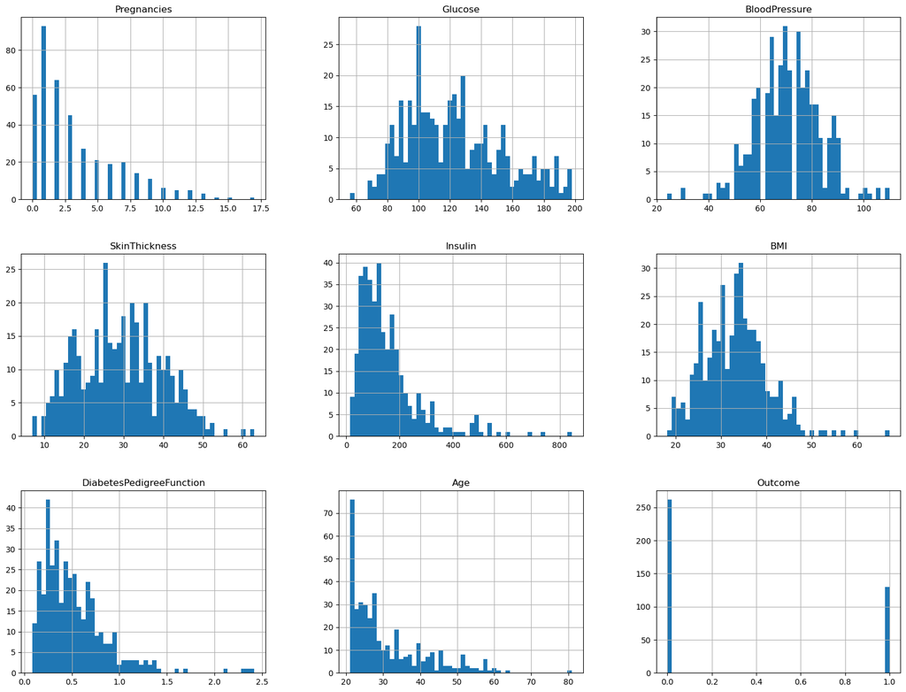

```python
# Histogram
data_all.hist(bins=50, figsize=(20, 15))
plt.show()
```

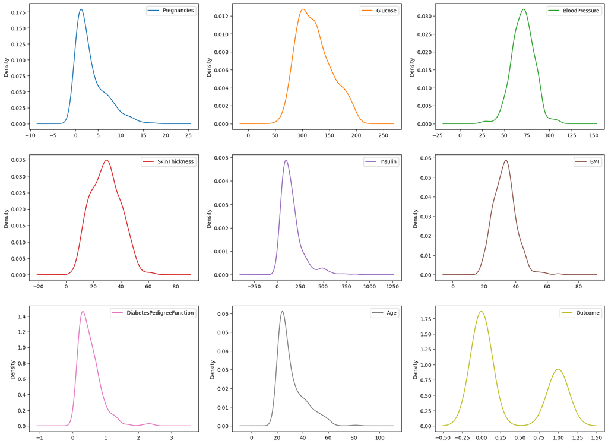

```python
# Density plots for all attributes to visualize the distribution of each attribute
data_all.plot(kind='density', subplots=True, layout=(3,3), figsize=(20, 15), sharex=False)
plt.show()
```

```
Pregnancies                    Axes(0.125,0.653529;0.227941x0.226471)
Glucose                     Axes(0.398529,0.653529;0.227941x0.226471)
BloodPressure               Axes(0.672059,0.653529;0.227941x0.226471)
SkinThickness                  Axes(0.125,0.381765;0.227941x0.226471)
Insulin                     Axes(0.398529,0.381765;0.227941x0.226471)
BMI                         Axes(0.672059,0.381765;0.227941x0.226471)
DiabetesPedigreeFunction           Axes(0.125,0.11;0.227941x0.226471)
Age                             Axes(0.398529,0.11;0.227941x0.226471)
Outcome                         Axes(0.672059,0.11;0.227941x0.226471)
dtype: object
```

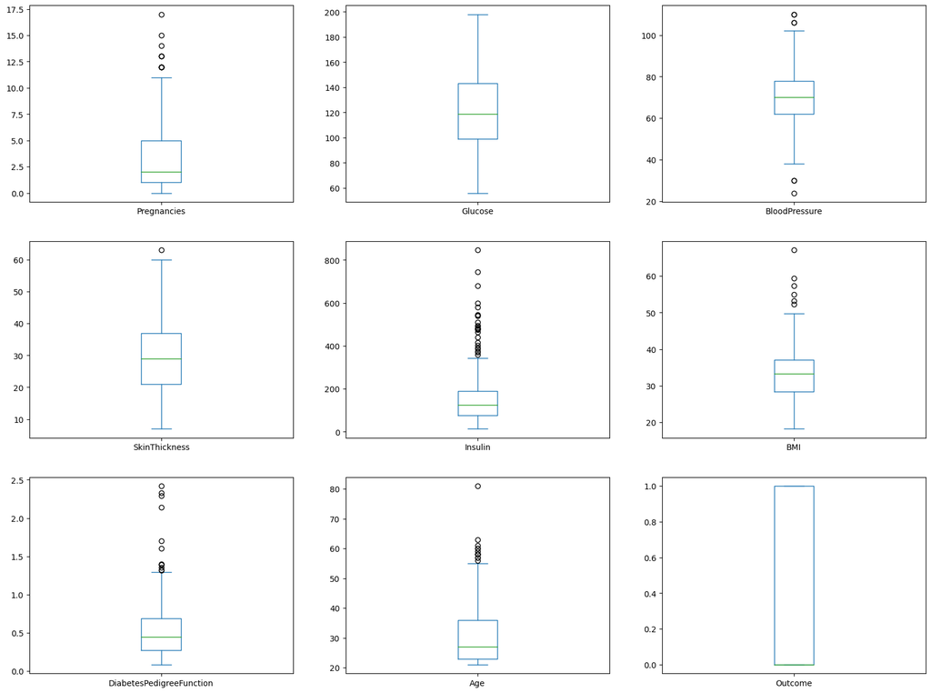

```python
#Box and Whisker plot to visualize the distribution of all atributes
data_all.plot(kind= 'box' , subplots=True, layout=(3,3), sharex=False, sharey=False, figsize=(20,15))
```

```python
#Skew of attributes distributions
skew=data_all.skew(axis = 1)
```

Correlation

```python
# Correlation between the different characteristics. Closer to 1 better is the correlation.

corr_matrix_pearson = data_all.corr(method='pearson')
corr_matrix_pearson
```

|  | Pregnancies | Glucose | BloodPressure | SkinThickness | Insulin | BMI | DiabetesPedigreeFunction | Age | Outcome |
| --- | --- | --- | --- | --- | --- | --- | --- | --- | --- |
| Pregnancies | 1.000000 | 0.198291 | 0.213355 | 0.093209 | 0.078984 | -0.025347 | 0.007562 | 0.679608 | 0.256566 |
| Glucose | 0.198291 | 1.000000 | 0.210027 | 0.198856 | 0.581223 | 0.209516 | 0.140180 | 0.343641 | 0.515703 |
| BloodPressure | 0.213355 | 0.210027 | 1.000000 | 0.232571 | 0.098512 | 0.304403 | -0.015971 | 0.300039 | 0.192673 |
| SkinThickness | 0.093209 | 0.198856 | 0.232571 | 1.000000 | 0.182199 | 0.664355 | 0.160499 | 0.167761 | 0.255936 |
| Insulin | 0.078984 | 0.581223 | 0.098512 | 0.182199 | 1.000000 | 0.226397 | 0.135906 | 0.217082 | 0.301429 |
| BMI | -0.025347 | 0.209516 | 0.304403 | 0.664355 | 0.226397 | 1.000000 | 0.158771 | 0.069814 | 0.270118 |
| DiabetesPedigreeFunction | 0.007562 | 0.140180 | -0.015971 | 0.160499 | 0.135906 | 0.158771 | 1.000000 | 0.085029 | 0.209330 |
| Age | 0.679608 | 0.343641 | 0.300039 | 0.167761 | 0.217082 | 0.069814 | 0.085029 | 1.000000 | 0.350804 |
| Outcome | 0.256566 | 0.515703 | 0.192673 | 0.255936 | 0.301429 | 0.270118 | 0.209330 | 0.350804 | 1.000000 |

There are no strong correlation between the features. The 'strongest' ones are the following (as expected): Age x pregnancies (0.68) - Older women tend to have higher number of pregnancies Glucose x insulin (0.58) Glucose x outcome (0.52) - Women that have higher level of glucose tend to have higher level of insulin and have DM Skin fold thickness x BMI (0.66) - Women with higher skin fold thickness value have higher BMI (and probably are overweight/obese) Negative correlation: BMI x Pregnancies (-0.025) Blood Pressure x Diabetes Pedigree Function (-0.016)

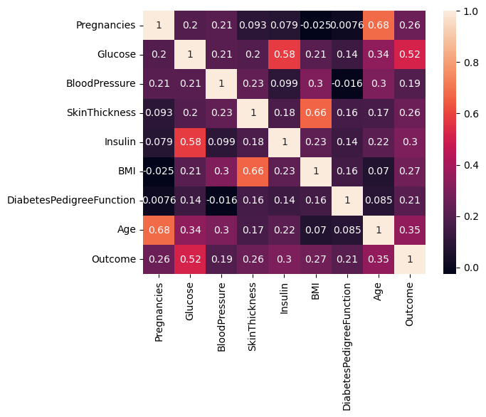

```python
sns.heatmap(corr_matrix_pearson, annot = True)
```

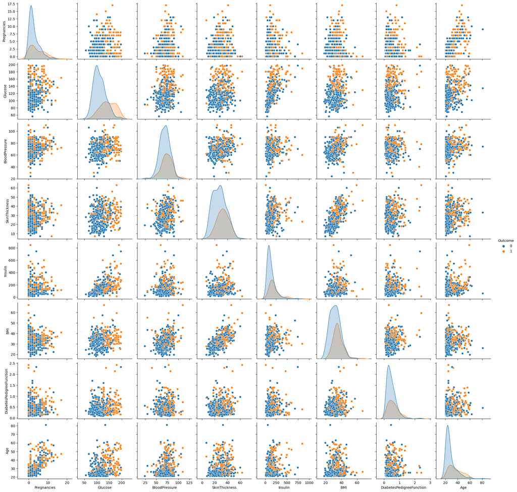

```python
# Pairplot

sns.pairplot(data_all, hue='Outcome')
```

Diabetic women tend to show larger values of age, BMI, insulin, skin thickness, blood pressure, and pregnancies. The feature that it is possible to see 2 distinct groups (diabetic and non diabetic) is glucose. https://www.collaborat.com/pima-diabetes-data-discovery-predictive-model/